# Basic network statistics

Firstly we look at the number of nodes, number of edges and average degree for each window size for the whole period. Note that "number of nodes" means number of individuals who were involved in at least one interaction within the relevant period.

## Number of nodes

First we examine how the number of nodes is reported according to each window size. We see that:

- The values for the year and the month window diverge by huge scales. This suggests that there is an important distinction to be made about reported "total" number of users vs "active" number of users for social networks.
- On medium scales of a month and week, we see 'bumps' following news events of interest to the Gab community such as the Trump election in Nov 16 and Charlottesville "Unite the Right" rally in Aug 17, which seem to be obscured in larger timescales and just noise in smaller scales. Perhaps weekly/monthly windows are a good candidate size for time series anomaly detection tasks?

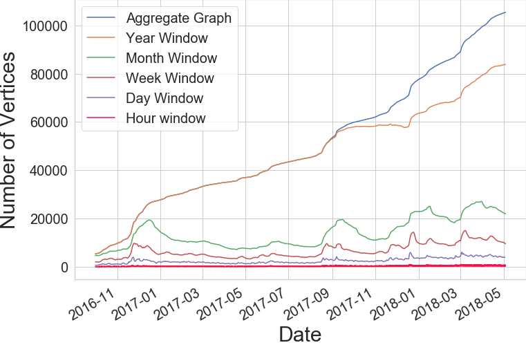

## Number of edges

Not much to say here apart from, again, the hugely differing scales of looking at a month vs a year.

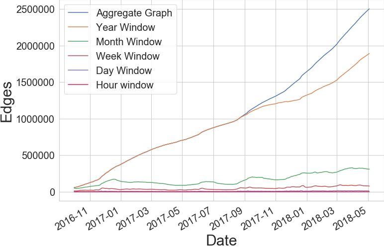

## Average degree

Calculated as 2x|edges|/|vertices|. We see that:

- For medium sized windows this is largely varying, with the 'dips' being caused by the bursts in number of vertices.
- For daily and hourly windows, it seems to be just constant + random noise (or constant+seasonal, I haven't looked into it yet.) It just seems interesting to me that there's seemingly no trend for the hour one compared to other sizes.

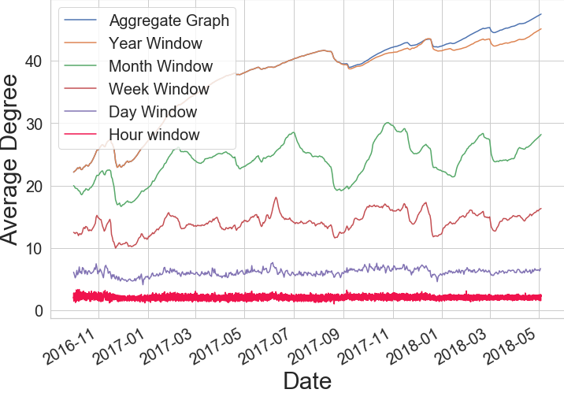

# Connected Components Analysis

This section contains the analysis of the size/proportion of the largest connected components, as well as the number of connected components. In the proportion and number, we exclude components comprising just one edge (two nodes) from the calculations.

## Proportion (without isolated nodes)

We measure the size of the largest connected component as a proportion of the size of the whole graph for that window.

### Whole time period

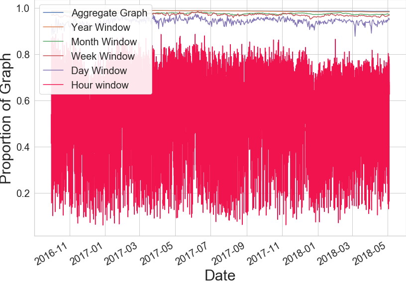

### Zoomed in

When zooming in to just a month subset of data, we see that the hourly window size is actually showing diurnal behaviour which we will explore later.

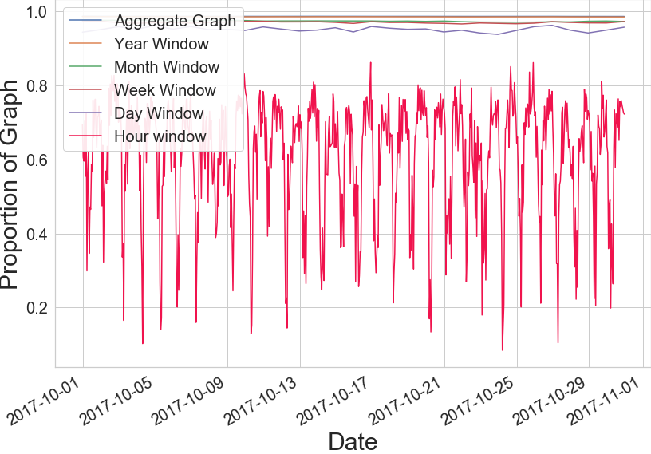

## Size of the largest connected component

On the whole, this shows similar behaviour to just the number of vertices.

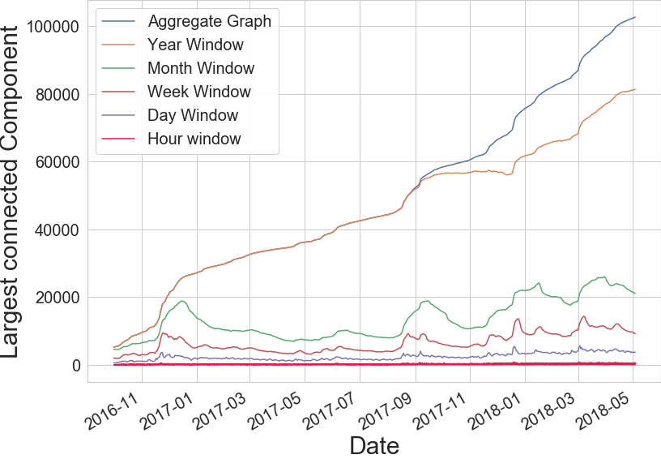

## Number of connected components

This seems to be similar in trend to the size of the largest (note the much smaller scale of ~600 components in total).

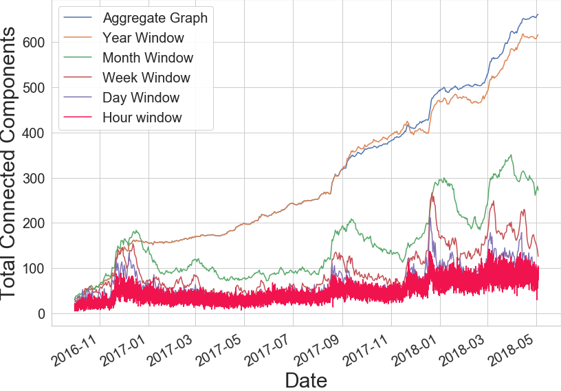

## At what size does the giant component break?

The plot below shows a CDF of the 'proportion' data for different window sizes, with particular attention to sizes between an hour and a day. Would be maybe helpful to provide a takeaway statistic like "for all window sizes, there's a component of size x% for y% of the time.

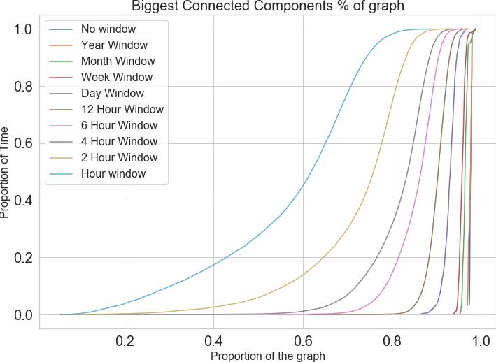

## Diurnal activity as shown by the hourly window

Batching the data by hour of the day we can see some diurnal behaviour as it's a mostly US-based platform.

### Initial box plot

There are definitely some issues with the outliers in the Seaborn boxplotting function (it is a bit black-box and I'm a bit worried how it is deciding that something is an outlier) so happy to let this go, THE BEAUTIFUL COLOURS THOUGH!!

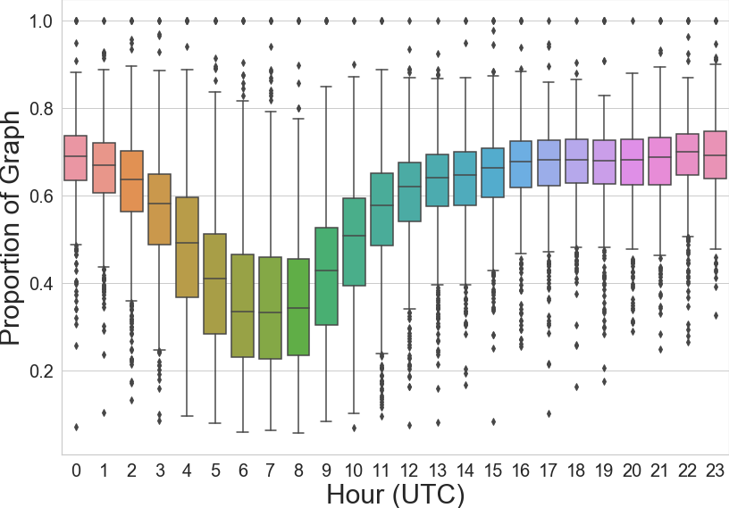

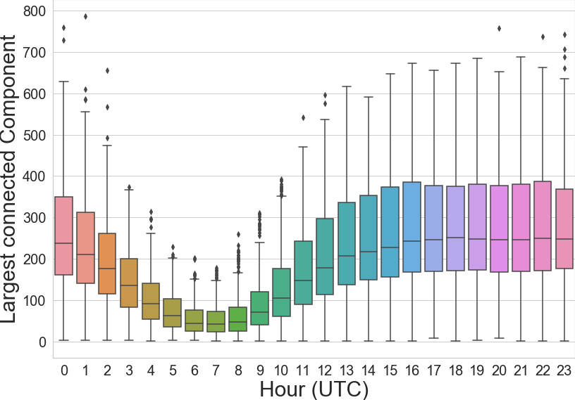

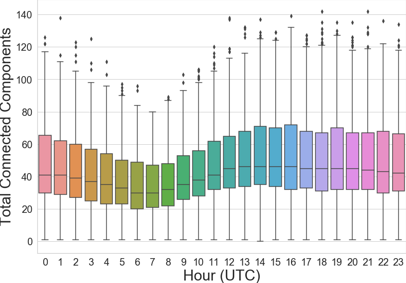

### Time-series analysis of the LCC in the hour window

This section explores deeper the existence of periodic/diurnal behaviour in the size/proportion of giant component size using fourier analysis. We will look first at the proportion data.

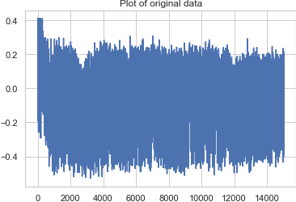

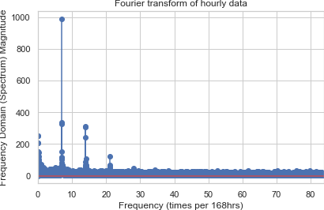

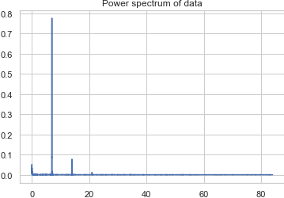

Below is the inverse Fourier transform (IFT) of the first few frequencies, showing the 'hum'.

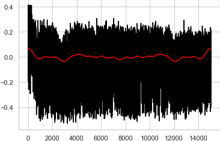

The IFT of the largest magnitude 10 frequencies looks fairly as expected, looking like a sine wave with 24h period.

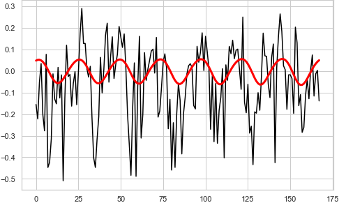

If we allow the IFT of the largest 240 harmonics we actually see a second slightly smaller peak slightly before a bigger peak, suggesting the presence of a European userbase.

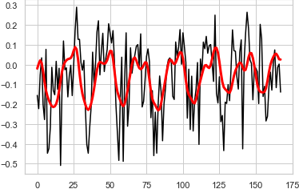

The following plot is the red line in the previous plot plotted against a 4hr behind version of itself -- it doesn't really add anything but I just want to keep the picture for it somewhere as it's quite pretty!

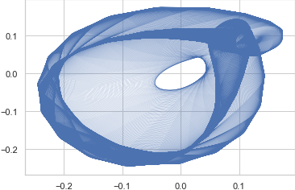

This following subsection definitely needs more attention from me but is essentially doing the same process but for the absolute size of the LCC, and shows that if we look at the absolute size rather than proportion, we see not just a 24hr frequency but a weekly frequency (component is smaller at weekends)/

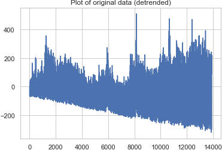

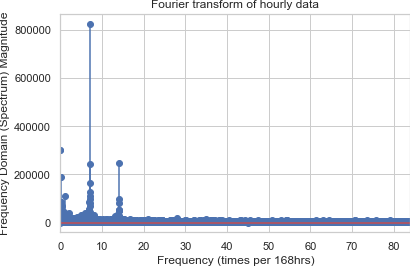

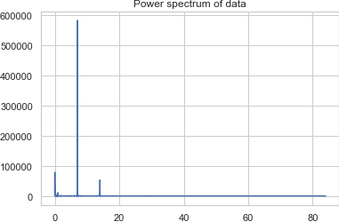

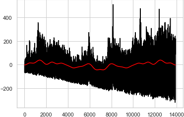

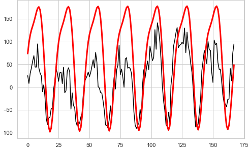

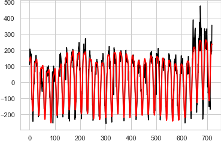

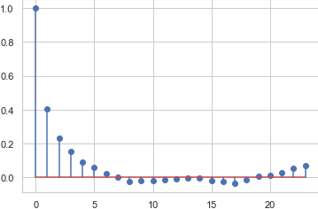

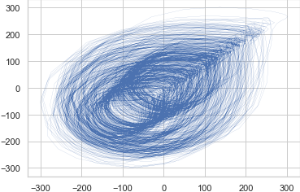

## Comparison with shuffled timestamps null model

Keep the same links but reorder their timestamps randomly, so that the rate of edge activity is conserved and that the aggregate graph is identical. For more detail on this null model, take a look at [Temporal Networks](https://arxiv.org/pdf/1108.1780.pdf), P. Holme, J. Saramaki (2011) under the heading Randomly Permuted Times (p17).

### Proportion: Hour window

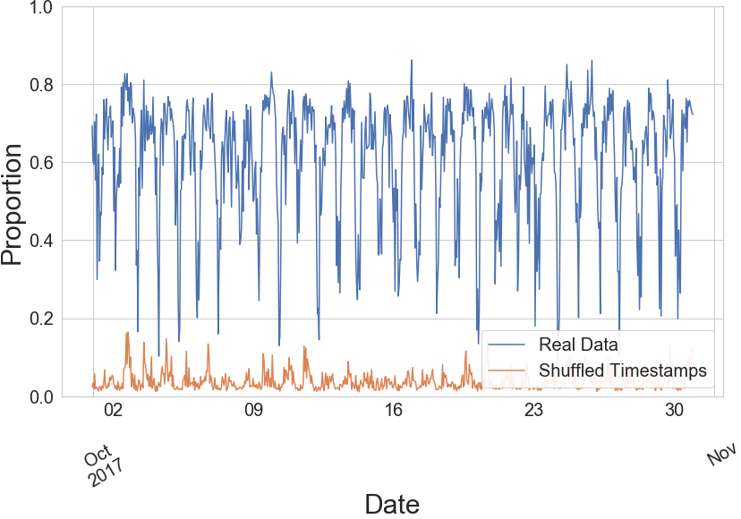

### Proportion: Day window

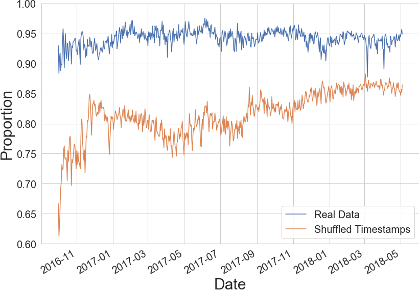

### Proportion: Week Window

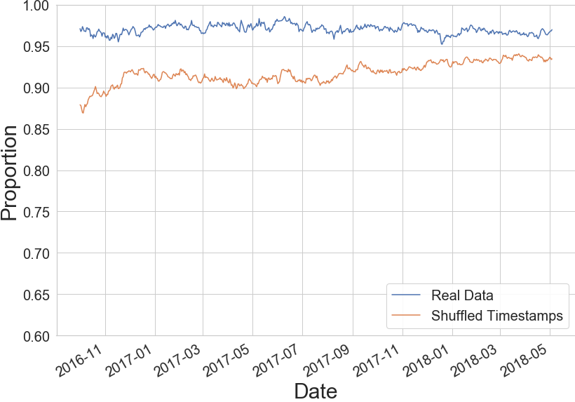

### Proportion: Month window

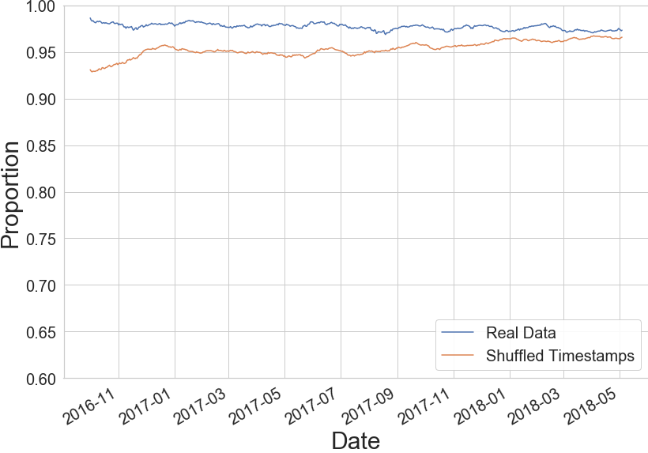

### Proportion: Year window

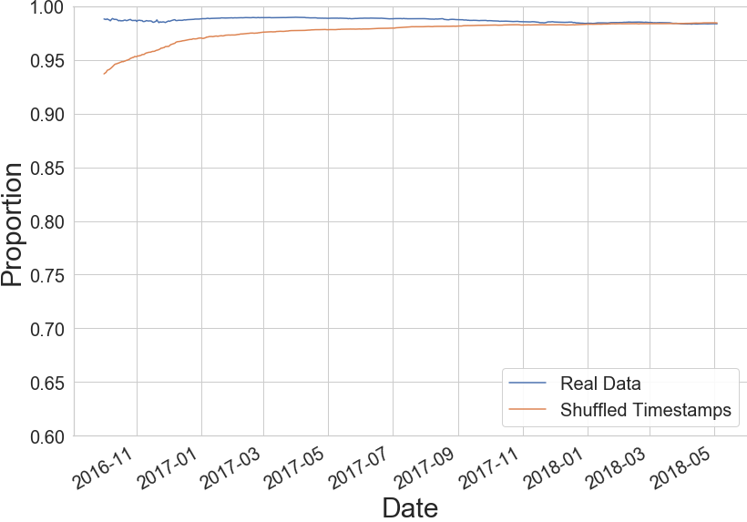